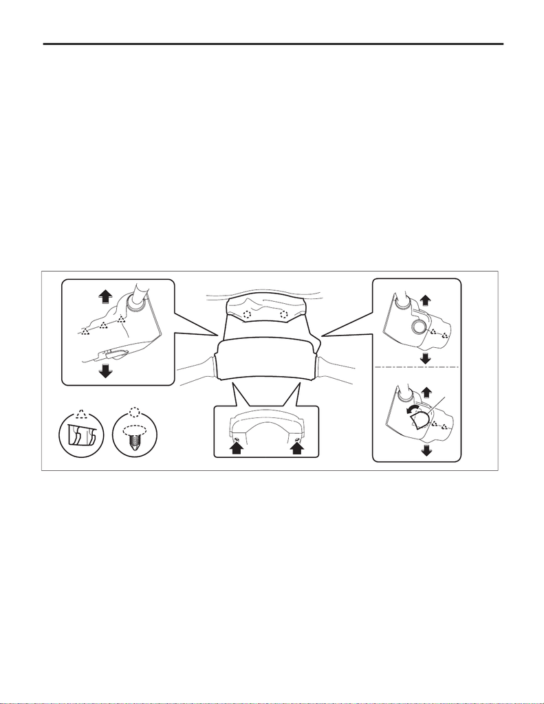

LI-18

Combination Switch (Light)

LIGHTING SYSTEM

12.Combination Switch (Light)

A: REMOVAL

CAUTION:

Before handling the airbag module, refer to “CAUTION” of “General Description” in “AIRBAG SYS-

TEM”. <Ref. to AB-9, CAUTION, General Description.>

1) Set the tire to the straight-ahead position.

2) Disconnect the ground cable from battery and wait for at least 60 seconds before starting work. <Ref. to

NT-5, BATTERY, NOTE, Note.>

NOTE:

For models other than STI model, disconnect the ground terminal from battery sensor.

3) Remove the driver’s airbag module. <Ref. to AB-33, REMOVAL, Driver’s Airbag Module.>

4) Remove the steering wheel. <Ref. to PS-16, REMOVAL, Steering Wheel.>

5) Remove the cover assembly - column.

(1) Release the clips, and remove the cover assembly - steering UPR.

(2) Remove the screws.

(3) Remove the cap - key cylinder (a). (Model with keyless access)

(4) Release the claw, and remove the cover assembly - column UPR and the cover assembly - column

LWR.

6) Remove the steering roll connector. <Ref. to AB-60, REMOVAL, Roll Connector.>

7) Remove the combination switch (wiper). <Ref. to WW-8, REMOVAL, Combination Switch (Wiper).>

A Keyless entry model B Keyless access model

LI-01710

(a)

A

B

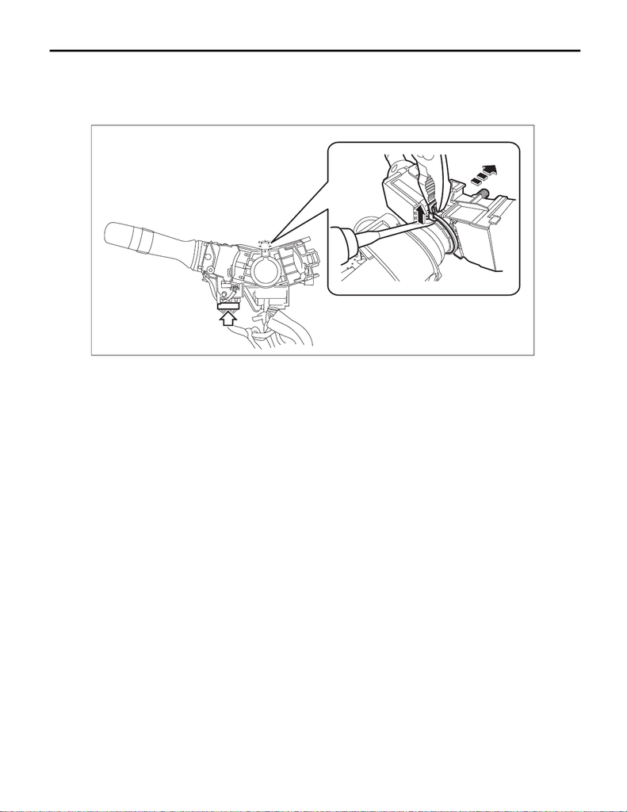

LI-19

Combination Switch (Light)

LIGHTING SYSTEM

8) Remove the switch assembly - combination turn dimmer.

(1) Disconnect the connector.

(2) Using pliers, loosen the clamp.

(3) With the clamp loosened, release the claw using a flat tip screwdriver, and remove the switch assem-

bly - combination turn dimmer.

B: INSTALLATION

CAUTION:

• Before handling the airbag module, refer to “CAUTION” of “General Description” in “AIRBAG SYS-

TEM”. <Ref. to AB-9, CAUTION, General Description.>

• Do not allow harness and connectors to interfere or get tangled up with other parts.

• If the steering wheel and steering angle sensor (steering roll connector) are removed, perform

“VDC sensor midpoint setting mode” of the VDC. <Ref. to VDC-16, VDC SENSOR MIDPOINT SETTING

MODE, ADJUSTMENT, VDC Control Module and Hydraulic Control Unit (VDCCM&H/U).>

1) Install the switch assembly - combination turn dimmer.

2) Install the combination switch (wiper).

3) Install the steering roll connector. <Ref. to AB-61, INSTALLATION, Roll Connector.>

4) Install the cover assembly - column.

5) Install the steering wheel.

Tightening torque:

39 N·m (4.0 kgf-m, 28.8 ft-lb)

Clearance:

Between cover assembly - column and steering wheel: 4 — 6 mm (0.16 — 0.24 in)

6) Install the driver’s airbag module. <Ref. to AB-34, INSTALLATION, Driver’s Airbag Module.>

7) Connect the battery ground terminal. <Ref. to NT-5, BATTERY, NOTE, Note.>

NOTE:

For models other than STI model, connect the ground terminal to battery sensor.

LI-01711

[figure not shown]

LI-20

Combination Switch (Light)

LIGHTING SYSTEM

C: INSPECTION

1) Measure the resistance between connector terminals.

Preparation tool:

Circuit tester

• Lighting switch

• Dimmer & passing switch

• Turn signal switch

• Front fog light switch

2) Replace the switch assembly - combination turn dimmer if the inspection result is not within the standard

value.

LI-01712

1

4

5

6

7

8

9

10

13

14

15

16

17

18

19

20

Terminal No. Inspection conditions Standard

18 — 12

19 — 12

20 — 12

Switch OFF 1 MΩ or more

19 — 12 Switch AUTO Less than 1 Ω

18 — 12 Switch 1 (TAIL) Less than 1 Ω

18 — 12

20 — 12

Switch 2 (HEAD) Less than 1 Ω

Terminal No. Inspection conditions Standard

11 — 12

17 — 12

Switch PASS Less than 1 Ω

11 — 12 Switch UP Less than 1 Ω

Terminal No. Inspection conditions Standard

13 — 12 Switch TURN (RH) Less than 1 Ω

15 — 12 Switch TURN (LH) Less than 1 Ω

Terminal No. Inspection conditions Standard

4 — 3

Switch OFF 1 MΩ or more

Switch ON Less than 1 Ω